# Lab 3: Mammal Sleep Patterns

Merhan Ghandehari

February 6, 2016

```
##                    Species       BodyWt            BrainWt
##  Africanelephant       : 1   Min.   :   0.005   Min.   :   0.14
##  Africangiantpouchedrat: 1   1st Qu.:   0.600   1st Qu.:   4.25
##  ArcticFox             : 1   Median :   3.342   Median :  17.25
##  Arcticgroundsquirrel  : 1   Mean   : 198.790   Mean   : 283.13
##  Asianelephant         : 1   3rd Qu.:  48.203   3rd Qu.: 166.00
##  Baboon                : 1   Max.   :6654.000   Max.   :5712.00
##  (Other)               :56
##   NonDreaming        Dreaming       TotalSleep       LifeSpan
##  Min.   : 2.100   Min.   :0.000   Min.   : 2.60   Min.   :  2.000
##  1st Qu.: 6.250   1st Qu.:0.900   1st Qu.: 8.05   1st Qu.:  6.625
##  Median : 8.350   Median :1.800   Median :10.45   Median : 15.100
##  Mean   : 8.673   Mean   :1.972   Mean   :10.53   Mean   : 19.878
##  3rd Qu.:11.000   3rd Qu.:2.550   3rd Qu.:13.20   3rd Qu.: 27.750
##  Max.   :17.900   Max.   :6.600   Max.   :19.90   Max.   :100.000
##  NA's   :14       NA's   :12      NA's   :4       NA's   :4
##    Gestation        Predation        Exposure         Danger
##  Min.   : 12.00   Min.   :1.000   Min.   :1.000   Min.   :1.000
##  1st Qu.: 35.75   1st Qu.:2.000   1st Qu.:1.000   1st Qu.:1.000
##  Median : 79.00   Median :3.000   Median :2.000   Median :2.000
##  Mean   :142.35   Mean   :2.871   Mean   :2.419   Mean   :2.613
##  3rd Qu.:207.50   3rd Qu.:4.000   3rd Qu.:4.000   3rd Qu.:4.000
##  Max.   :645.00   Max.   :5.000   Max.   :5.000   Max.   :5.000
##  NA's   :4
```

```
##  Predation Exposure Danger
##  1:14      1:27     1:19
##  2:15      2:13     2:14
##  3:12      3: 4     3:10
##  4: 7      4: 5     4:10
##  5:14      5:13     5: 9
```

Variable Description BodyWt body weight (kg) BrainWt brain weight (g) NonDreaming slow wave (“nondreaming”) sleep (hrs/day) Dreaming paradoxical (“dreaming”) sleep (hrs/day) TotalSleep total sleep, sum of slow wave and paradoxical sleep (hrs/day) LifeSpan maximum life span (years) Gestation gestation time (days) Predation predation index (1-5) 1 = minimum (least likely to be preyed upon); 5 = maximum (most likely to be preyed upon) Exposure sleep exposure index (1-5) 1 = least exposed (e.g. animal sleeps in a well-protected den); 5 = most exposed Danger overall danger index (1-5) (based on the above two indices and other information) 1 = least danger (from other animals); 5 = most danger (from other animals)

```r
# cerate a new variable in mammals dataframe named BrainPct (the percentage of total body weight that the brain weighs)
# BrainPct = BrainWt / (BodyWt * 1000)
mammals$BrainPct = (mammals$BrainWt / (mammals$BodyWt * 1000))*100

#the highest BrainPct
HighestBrainPct = mammals[mammals$BrainPct == max(mammals$BrainPct), "Species"]
print(HighestBrainPct)
```

```
## [1] Groundsquirrel
## 62 Levels: Africanelephant Africangiantpouchedrat ... Yellow-belliedmarmot
```

```r
# HighestBrainPct = mammals[which.max(mammals$BrainPct), "Species"]


# the lowest BrainPct
LowestBrainPct = mammals[mammals$BrainPct == min(mammals$BrainPct), "Species"]
print(LowestBrainPct)
```

```
## [1] Africanelephant
## 62 Levels: Africanelephant Africangiantpouchedrat ... Yellow-belliedmarmot
```

```r
# the mean of BrainPct
MeanBrainPct = mean(mammals$BrainPct)
print(MeanBrainPct)
```

```
## [1] 0.9624214
```

```r
# the median of BrainPct
MedianBrainPct = median(mammals$BrainPct)
print(MedianBrainPct)
```

```
## [1] 0.6610856
```

```
## Package 'sm', version 2.2-5.4: type help(sm) for summary information
```

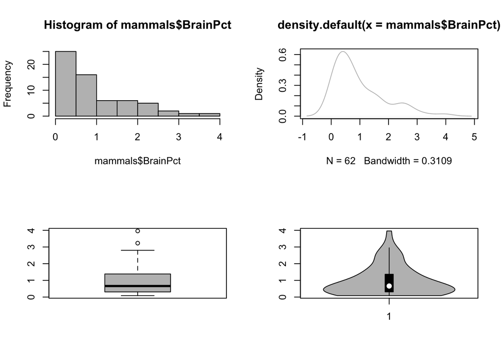

- the distribution appear positively (right) skewed

```r
library(moments)
skewness(mammals$BrainPct)
```

```
## [1] 1.315525
```

```r
library(e1071)
skewness(mammals$BrainPct)
```

```
## [1] 1.283827
```

The skewness here is 1.315525 or 1.283827. This value implies that the distribution of the data isskewed to the right or positively skewed.

3. a scatterplot with LifeSpan on the y-axis and Gestation on the x-axis

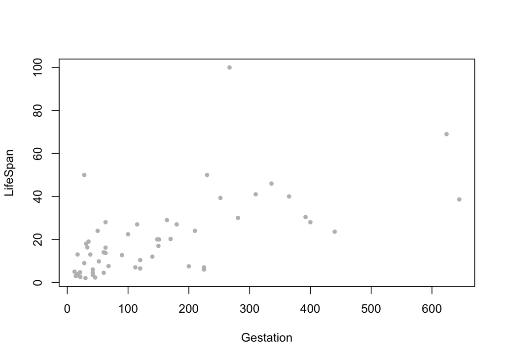

```r
plot(mammals$Gestation, mammals$LifeSpan,
     xlab = "Gestation",
     ylab = "LifeSpan",
     pch = 20,
     col = "grey")
```

# get rid of all of the plots # dev.off(dev.list()[“RStudioGD”])

4. a boxplot that compares body weight across the five Danger levels.

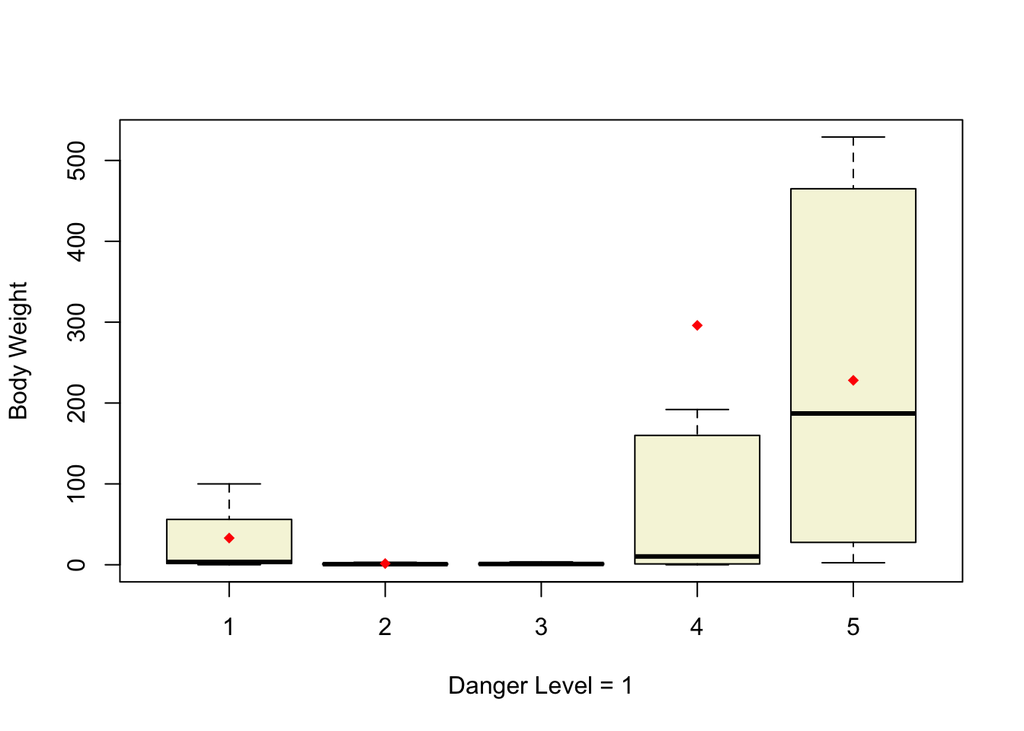

4.2. a boxplot that compares TotalSleep across the five Danger levels

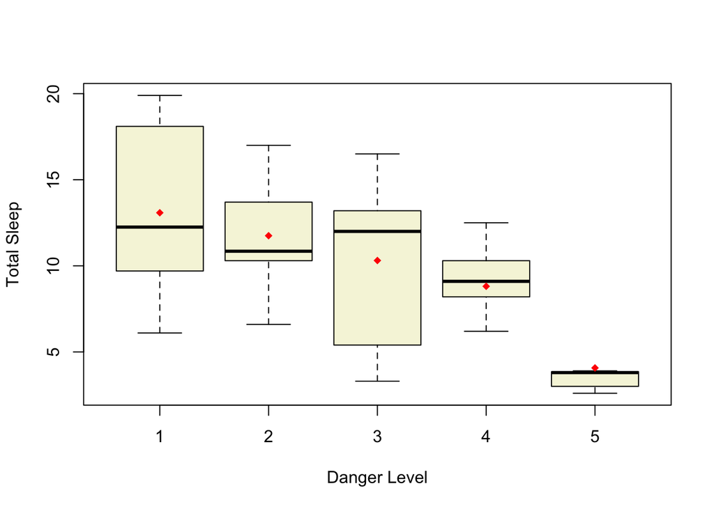

- What inferences can you make about the sleeping conditions of an animal from this box plot?

# Data Transformations

5-

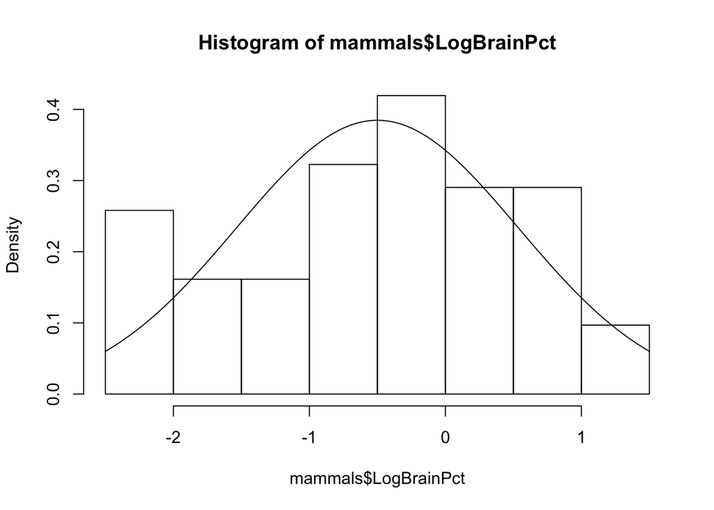

```r
mammals$LogBrainPct = log(mammals$BrainPct)
hist(mammals$LogBrainPct, freq=FALSE)
mu = mean(mammals$LogBrainPct)
std = sd(mammals$LogBrainPct)
curve(dnorm(x, mean=mu, sd=std), add=TRUE)  # Add curve to plot
```

6- Data transformation is used the data does not have a normal distribution.

```
There are many reasons for transformation. The list here is not
comprehensive
    1. Convenience
    2. Reducing skewness
    3. Equal spreads
    4. Linear relationships
    5. Additive relationships
```

linear tranformation is used to change data from one sclae to another (such as z score), but it does not change the shape of the distribution with transformation you can chnage an exponentiol corelation to a linear corelation (y=m^x -> log y = x log m -> log y = ax + b) so if we log y and see that we have a straight line we can conclude that the original data has been exponential. if it was not an staright line, you should log both x and y, and then if the scatter plot was straght then the original data is power

# Correlation Analysis

7. correlation between lifespan and gestation period

```r
cor(mammals$LifeSpan, mammals$Gestation, use = "complete.obs", method = "pearson")
```

```
## [1] 0.6148488
```

```r
cor(mammals$LifeSpan, mammals$Gestation, use = "complete.obs", method =  "kendall")
```

```
## [1] 0.4866147
```

```r
cor(mammals$LifeSpan, mammals$Gestation, use = "complete.obs", method = "spearman")
```

```
## [1] 0.6728017
```

Yes, from plot in question 3, it was clear that there is a positive linear relationship between these two variables.

8-

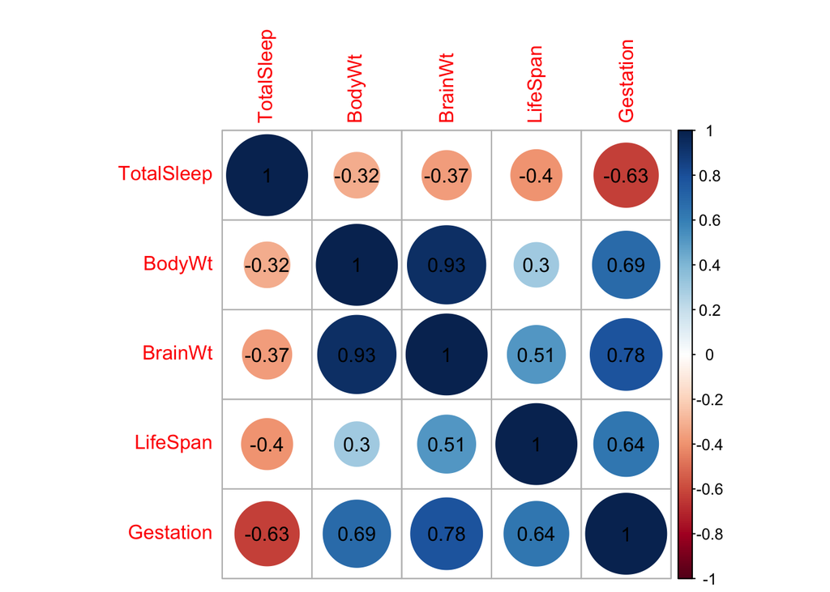

```r
MammalsSubset = data.frame(TotalSleep = mammals$TotalSleep, BodyWt = mammals$BodyWt, BrainWt = mammals$BrainWt, LifeSpan = mammals$LifeSpan, Gestation = mammals$Gestation)

# mammals[,sapply(mammals, is.numeric)] # this code is extract the numeric attributes, but here we don't need all of the numeric attributes

MammalsSubset_corr = cor(MammalsSubset, use = "complete.obs", method = "pearson") # get correlations

library('corrplot') #package corrplot
corrplot(MammalsSubset_corr, method = "circle", addCoef.col = "black") #plot matrix
```

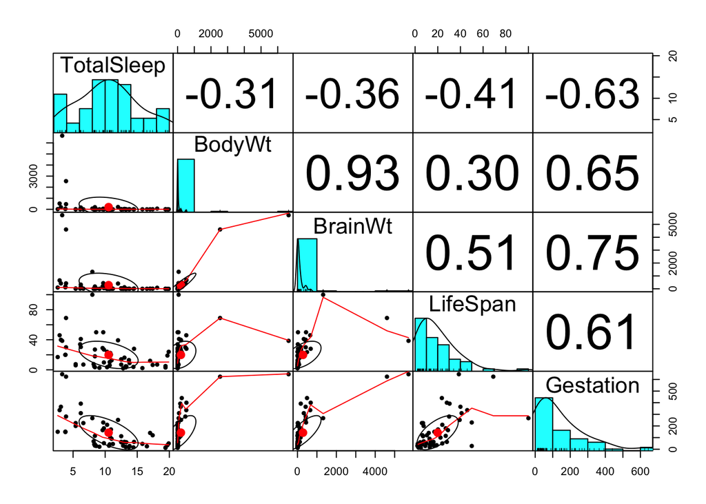

```r
# Use "Pairs Plot" from "psych" package to visualize scatter plot
library("psych")
pairs.panels(MammalsSubset, gap = 0)
```

Based on Pearson’s correlation coefficient, which two variables are most and least correlated with each-other?

Body weight and brain weight are the most correlated (0.93) and body weight and life span are the least correlated (0.30).